# projet App Stat

### A.3.Complexity pruning

L’utilsation du modèle d’arbre de décision avec la complexity pruning nous permet d’avoir le nombre d’arbre optimal et le *cp* optimal pour notre modèle.

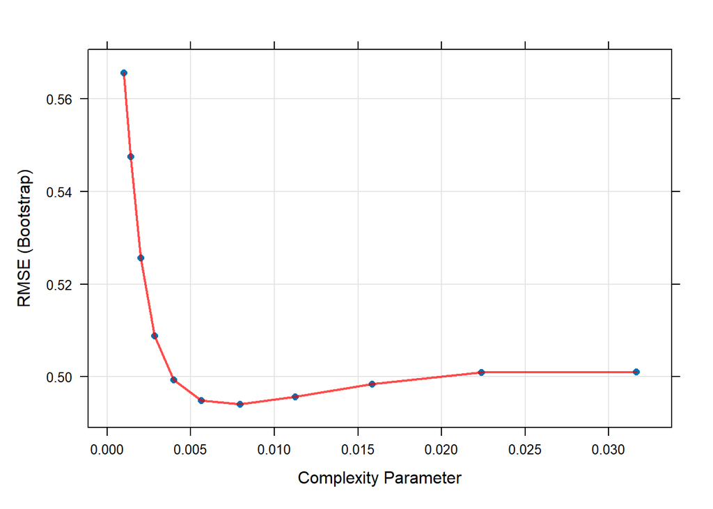

```
##            cp
## 7 0.007943282
```

```r
library(caret)
library(doParallel)
library(rpart)

nrcore <- 8
cl <- makeCluster(nrcore)
registerDoParallel(cl)

bootTunes <- 11
method <- "boot"
numbers <- 50

bootControl <- trainControl(method = method,
                            number = numbers,
                            savePredictions = "final",
                            p = 0.3)

# Grille de valeurs pour cp (paramètre de complexité)
alpha <- 10^seq(from = -1.5, to = -3, length.out = bootTunes)


set.seed(123)
cptree <- train(log(shares) ~ timedelta + n_tokens_title + n_tokens_content + n_non_stop_unique_tokens + num_hrefs + num_self_hrefs + num_imgs + num_videos + average_token_length + num_keywords + data_channel_is_lifestyle + data_channel_is_entertainment + data_channel_is_bus + data_channel_is_socmed + data_channel_is_tech + kw_min_min + kw_max_min + kw_avg_min + kw_min_max + kw_avg_max + kw_min_avg + kw_max_avg + kw_avg_avg + weekday_is_monday + weekday_is_tuesday + weekday_is_wednesday + weekday_is_thursday + weekday_is_friday + weekday_is_saturday + global_subjectivity + global_sentiment_polarity + global_rate_positive_words + global_rate_negative_words + avg_positive_polarity + min_positive_polarity + max_positive_polarity + avg_negative_polarity + min_negative_polarity + max_negative_polarity + title_subjectivity + title_sentiment_polarity + abs_title_sentiment_polarity,
               data = onp1,
               method = "rpart",
               trControl = bootControl,
               tuneGrid = expand.grid(cp = alpha))

# Arrêter le cluster parallèle
stopCluster(cl)
registerDoSEQ()

# Afficher le graphique du modèle pour visualiser les performances à différents niveaux de cp
plot(cptree)
```

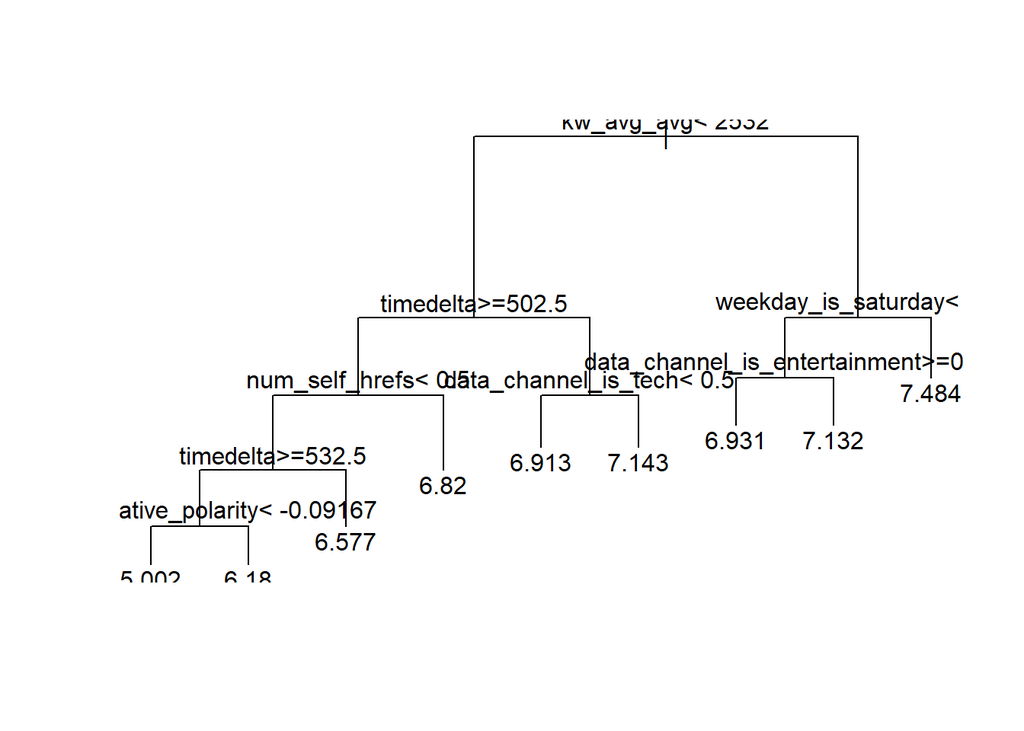

**Importance des variables**

L’importance des variables dans un modèle prédictif est une mesure statistique permettant d’évaluer l’influence de chaque variable indépendante sur la variable cible. Elle permet de distinguer les variables ayant un impact significatif de celles qui contribuent peu à la capacité prédictive du modèle. Cette connaissance oriente l’optimisation du modèle en identifiant les facteurs clés à intégrer, et aide à comprendre les relations sous-jacentes dans les données, facilitant ainsi les décisions basées sur le modèle.

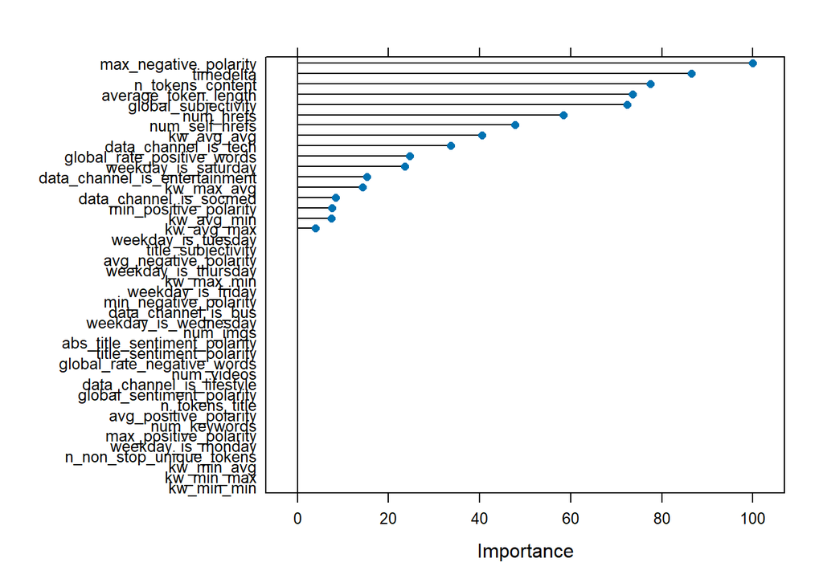

```r
varImportance <- varImp(cptree, scale = FALSE)$importance

varImportanceDF <- data.frame(Importance = varImportance[, 1], row.names = NULL)
varImportanceDF$Variable <- rownames(varImportance)

# Trier par importance décroissante
varImportanceDF <- varImportanceDF[order(-varImportanceDF$Importance), ]

# Sélectionner les 17 variables les plus importantes
top17Variables <- head(varImportanceDF, 17)

# Afficher les noms et l'importance
print(top17Variables)
```

```
##    Importance                      Variable
## 11 0.33756716         max_negative_polarity
## 16 0.29190902                     timedelta
## 13 0.26152439              n_tokens_content
## 1  0.24866159          average_token_length
## 6  0.24454449           global_subjectivity
## 14 0.19710012                     num_hrefs
## 15 0.16106989                num_self_hrefs
## 7  0.13677444                    kw_avg_avg
## 4  0.11350310          data_channel_is_tech
## 5  0.08302789    global_rate_positive_words
## 17 0.07977434           weekday_is_saturday
## 2  0.05160813 data_channel_is_entertainment
## 10 0.04842337                    kw_max_avg
## 3  0.02822124        data_channel_is_socmed
## 12 0.02567893         min_positive_polarity
## 9  0.02498718                    kw_avg_min
## 8  0.01321488                    kw_avg_max
```

### A.4 Bagged Trees:

Les modèles bagged trees (arbres agrégés) sont une évolution des arbres de décision individuels qui améliorent leur précision et robustesse. Le bagging consiste à créer plusieurs arbres de décision sur des échantillons aléatoires du jeu de données (avec remise), puis à agréger leurs prédictions. Cette technique réduit la variance des prédictions, limitant ainsi le surajustement typique des arbres de décision individuels, sans augmenter significativement le biais.

Dans le contexte de la prédiction du nombre de partages d’articles, l’utilisation de bagged trees est pertinente car elle permet d’exploiter les avantages des arbres de décision, tels que la facilité d’interprétation et la gestion des interactions non linéaires, tout en améliorant la stabilité et la précision du modèle. Cette méthode est particulièrement importante lorsqu’on a un grand nombre de variables explicatives et qu’on cherche à éviter le risque de surajustement tout en maintenant une bonne capacité prédictive.

Dans ce modèle on va utiliser seulement les variables importantes dans qu’on a retrouvé dans le modèle d’arbre de décision.

```r
library(caret)
library(dplyr)


index_train <- createDataPartition(log(onp1$shares), p = 0.3, list = FALSE)
data_train <- onp1[index_train, ]
data_test <- onp1[-index_train, ]

set.seed(123)
control <- trainControl(method = "cv", number = 10)
model_bagged_tree <- train(formula2, data = data_train,
                           method = "treebag",
                           trControl = control)

# Résumé du modèle
print(model_bagged_tree)
```

```
## Bagged CART
##
## 1637 samples
##   17 predictor
##
## No pre-processing
## Resampling: Cross-Validated (10 fold)
## Summary of sample sizes: 1473, 1474, 1472, 1473, 1473, 1474, ...
## Resampling results:
##
##   RMSE       Rsquared   MAE
##   0.4894794  0.1192735  0.3691175
```

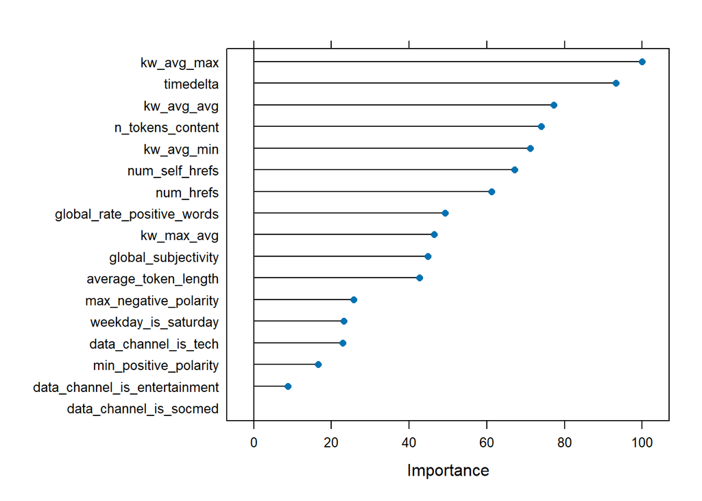

```r
plot(varImp(model_bagged_tree))
```

```r
# Prédiction sur l'ensemble de test
predictions <- predict(model_bagged_tree, newdata = data_test)

# Évaluation des performances du modèle
postResample(pred = predictions, obs = log(data_test$shares))
```

```
##      RMSE  Rsquared       MAE
## 0.4754228 0.1152738 0.3540713
```

## B. Foret aléatoire:

On s’interesse maintenant à une autre modèle de régression.

Le modèle Random Forest est une extension de l’arbre de décision qui optimise la précision prédictive et contrôle le surajustement par l’agrégation de multiples arbres. Chaque arbre est construit à partir d’un échantillon bootstrap du jeu de données et lors de la formation de chaque nœud, un sous-ensemble aléatoire de variables est considéré, ce qui augmente la diversité des arbres et réduit la corrélation entre eux. Ce modèle est particulièrement efficace pour gérer les ensembles de données avec un grand nombre de variables et peut capturer des interactions complexes entre les variables sans nécessiter de transformation ou de sélection manuelle. Sa facilité d’interprétation grâce à l’importance des variables et son efficacité dans les prédictions hors échantillon en font un choix robuste pour prédire le nombre de partages des articles.

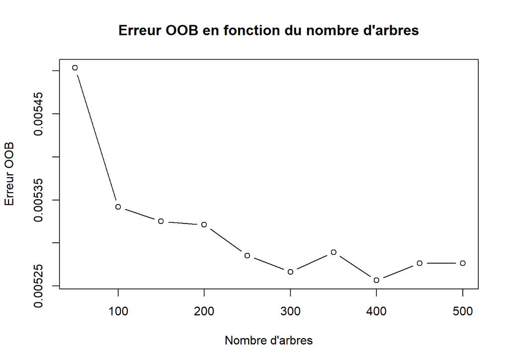

Le graphique montre l’erreur out-of-bag (OOB) en fonction du nombre d’arbres dans un modèle de forêt aléatoire. On observe une décroissance rapide de l’erreur avec l’augmentation du nombre d’arbres jusqu’à environ 300, puis la tendance se stabilise, indiquant peu ou pas d’amélioration avec l’ajout de plus d’arbres. Cela suggère qu’un modèle comprenant environ 300 arbres pourrait être suffisant pour minimiser l’erreur sans imposer de coût de calcul supplémentaire inutile.

```r
library(caret)
library(randomForest)

# Définir le nombre de cœurs à utiliser
nrcore <- detectCores()
cl <- makeCluster(nrcore)
registerDoParallel(cl)

set.seed(123)
data_rf <- onp
data_rf$shares <- log(data_rf$shares + 1) # Log-transform de la variable cible

# Créer un index d'entraînement avec 30% des données
index_train <- createDataPartition(data_rf$shares, p = 0.3, list = FALSE)
train_set <- data_rf[index_train, ]
test_set <- data_rf[-index_train, ]

# Configurer le contrôle de l'entraînement , numberà 100 iteration/ 50 pour moins de temps de run
control <- trainControl(method = "boot", number = 100, savePredictions = TRUE)

# Ajuster le modèle de forêt aléatoire

rf_model <- train(formula, data = train_set, method = "rf",
                  trControl = control, tuneLength = 5)
print(rf_model)
```

```
## Random Forest
##
## 1637 samples
##   42 predictor
##
## No pre-processing
## Resampling: Bootstrapped (100 reps)
## Summary of sample sizes: 1637, 1637, 1637, 1637, 1637, 1637, ...
## Resampling results across tuning parameters:
##
##   mtry  RMSE        Rsquared    MAE
##    2    0.07269742  0.09405432  0.05239410
##   12    0.07304777  0.08058048  0.05271787
##   22    0.07349597  0.07447609  0.05307582
##   32    0.07376155  0.07230964  0.05328755
##   42    0.07409550  0.06932364  0.05351679
##
## RMSE was used to select the optimal model using the smallest value.
## The final value used for the model was mtry = 2.
```

```r
# Arrêter le cluster parallèle pour libérer les ressources
stopCluster(cl)
registerDoSEQ()
```

Dans notre quête pour modéliser précisément le nombre de partages d’articles, l’utilisation de la forêt aléatoire (Random Forest) a démontré une capacité remarquable à synthétiser les interactions complexes entre les variables prédictives. Lors de l’ajustement du modèle, un nombre restreint de prédicteurs par arbre (mtry = 2) a été privilégié, ce qui a permis d’atteindre le niveau de RMSE le plus bas de notre série de tests, s’établissant à 0.0727. Cette approche a non seulement favorisé la simplicité et la généralité du modèle mais a aussi entravé efficacement le phénomène de surajustement souvent observé avec des méthodes plus flexibles. Bien que le pourcentage de variance expliquée par le modèle soit relativement modeste, le faible R-squared ne contre indique pas le fait que le modèle est parvenu à capturer de manière adéquate la structure sous-jacente de nos données.

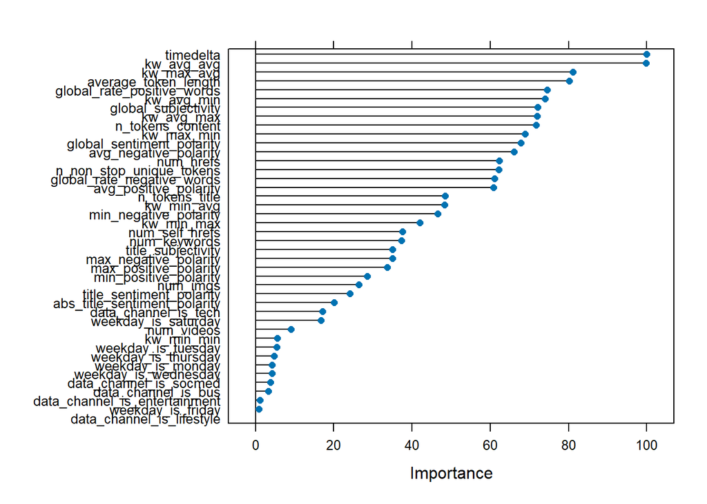

```
##      RMSE  Rsquared       MAE
## 0.4806977 0.1257282 0.3549391
```

Le modèle de forêt aléatoire affiche un RMSE de 0.4807, suggérant une moyenne modérée des écarts entre les valeurs prédites et observées. Avec un R-squared de 0.1257, le modèle explique une part limitée, mais non négligeable, de la variance des données, ce qui indique une certaine pertinence dans la capture de l’information contenue dans les variables prédictives. Le MAE, se situant à 0.3549, reflète une estimation assez proche des valeurs réelles, bien que des erreurs ponctuelles puissent être plus conséquentes.

Ce modèle de forêt aléatoire, tout en étant relativement simple, a révélé sa capacité à fournir une compréhension de base et une estimation raisonnablement précise de la dynamique influençant le nombre de partages d’articles. Il constitue un fondement solide pour des modèles prédictifs plus élaborés.

## C. GAM:

Le modèle GAM (Generalized Additive Model) est un type de modèle statistique flexible qui permet d’ajuster des relations non linéaires entre les variables indépendantes et la variable dépendante. Contrairement aux modèles linéaires classiques, le GAM utilise des fonctions lisses pour modéliser la dépendance, permettant une représentation plus précise et intuitive de l’impact des prédicteurs sur la variable cible. Cette caractéristique le rend particulièrement puissant pour la prédiction dans des situations où la relation entre les variables n’est pas strictement linéaire, offrant ainsi des prédictions améliorées et une meilleure compréhension des données.

### C.1: 1er model GAM:

D’abord, nous incluons toutes les variables sélectionnées précédemment, en considérant des relations non linéaires pour celle jugée pertinente.

```r
gam_model_1 <- mgcv::gam(log(shares) ~ s(kw_min_avg, bs = "cr")  + timedelta +  n_tokens_title + n_tokens_content +
    n_non_stop_unique_tokens + num_hrefs + num_self_hrefs + num_imgs +
    num_videos + average_token_length + num_keywords + as.factor(data_channel_is_lifestyle) +
    as.factor(data_channel_is_entertainment) + as.factor(data_channel_is_bus) + as.factor(data_channel_is_socmed) +
    as.factor(data_channel_is_tech) + kw_min_min + kw_max_min + kw_avg_min +
    kw_min_max + kw_avg_max + kw_max_avg + kw_avg_avg +
    as.factor(weekday_is_monday) + as.factor(weekday_is_tuesday) + as.factor(weekday_is_wednesday) +
    as.factor(weekday_is_thursday) + as.factor(weekday_is_friday) + as.factor(weekday_is_saturday) +
    global_subjectivity + global_sentiment_polarity + global_rate_positive_words +
    global_rate_negative_words + avg_positive_polarity + min_positive_polarity +
    max_positive_polarity + avg_negative_polarity + min_negative_polarity +
    max_negative_polarity + title_subjectivity + title_sentiment_polarity +
    abs_title_sentiment_polarity , data = onp1)
summary(gam_model_1)
```

```
##
## Family: gaussian
## Link function: identity
##
## Formula:
## log(shares) ~ s(kw_min_avg, bs = "cr") + timedelta + n_tokens_title +
##     n_tokens_content + n_non_stop_unique_tokens + num_hrefs +
##     num_self_hrefs + num_imgs + num_videos + average_token_length +
##     num_keywords + as.factor(data_channel_is_lifestyle) + as.factor(data_channel_is_entertainment) +
##     as.factor(data_channel_is_bus) + as.factor(data_channel_is_socmed) +
##     as.factor(data_channel_is_tech) + kw_min_min + kw_max_min +
##     kw_avg_min + kw_min_max + kw_avg_max + kw_max_avg + kw_avg_avg +
##     as.factor(weekday_is_monday) + as.factor(weekday_is_tuesday) +
##     as.factor(weekday_is_wednesday) + as.factor(weekday_is_thursday) +
##     as.factor(weekday_is_friday) + as.factor(weekday_is_saturday) +
##     global_subjectivity + global_sentiment_polarity + global_rate_positive_words +
##     global_rate_negative_words + avg_positive_polarity + min_positive_polarity +
##     max_positive_polarity + avg_negative_polarity + min_negative_polarity +
##     max_negative_polarity + title_subjectivity + title_sentiment_polarity +
##     abs_title_sentiment_polarity
##
## Parametric coefficients:
##                                             Estimate Std. Error t value
## (Intercept)                                6.801e+00  2.025e-01  33.585
## timedelta                                  2.830e-05  6.920e-05   0.409
## n_tokens_title                             5.401e-04  3.234e-03   0.167
## n_tokens_content                          -5.263e-05  3.879e-05  -1.357
## n_non_stop_unique_tokens                  -1.549e-01  1.249e-01  -1.241
## num_hrefs                                  4.657e-03  1.554e-03   2.996
## num_self_hrefs                             8.203e-03  3.441e-03   2.384
## num_imgs                                   3.215e-02  6.624e-03   4.853
## num_videos                                 3.266e-02  1.179e-02   2.770
## average_token_length                      -3.385e-02  3.002e-02  -1.128
## num_keywords                               9.043e-03  4.564e-03   1.981
## as.factor(data_channel_is_lifestyle)1     -7.666e-02  3.958e-02  -1.937
## as.factor(data_channel_is_entertainment)1 -9.127e-02  2.371e-02  -3.849
## as.factor(data_channel_is_bus)1            1.168e-01  2.183e-02   5.351
## as.factor(data_channel_is_socmed)1         2.469e-01  3.967e-02   6.225
## as.factor(data_channel_is_tech)1           1.832e-01  2.231e-02   8.213
## kw_min_min                                -2.042e-02  5.084e-03  -4.017
```

[output cut: 65 more lines]

```
## title_subjectivity                         0.18496
## title_sentiment_polarity                   0.18173
## abs_title_sentiment_polarity               0.99208
## ---
## Signif. codes:  0 '***' 0.001 '**' 0.01 '*' 0.05 '.' 0.1 ' ' 1
##
## Approximate significance of smooth terms:
##                 edf Ref.df     F p-value
## s(kw_min_avg) 3.475  4.214 10.14  <2e-16 ***
## ---
## Signif. codes:  0 '***' 0.001 '**' 0.01 '*' 0.05 '.' 0.1 ' ' 1
##
## Rank: 50/51
## R-sq.(adj) =   0.14   Deviance explained = 14.7%
## GCV = 0.22554  Scale est. = 0.2237    n = 5450
```

### C.2: Modele GAM sans variable non significatives

Notre modèle GAM révisé a été simplifié pour exclure les variables non significatives du premier modèle. Cette approche cible l’amélioration de la précision des prédictions en se concentrant sur les variables ayant un impact prouvé sur le nombre de partages des articles. Le nouveau modèle GAM incorpore seulement les prédicteurs avec des p-valeurs inférieures au seuil de significativité, ce qui devrait théoriquement améliorer la pertinence du modèle en éliminant le bruit introduit par les variables non pertinentes. Cela permet également de réduire la complexité du modèle, facilitant son interprétation et potentiellement améliorant la performance de validation croisée.

```r
library(mgcv)

# Construire le deuxième modèle GAM avec uniquement les variables significatives
gam_model_2 <- mgcv::gam(log(shares) ~
                           num_hrefs +
                           num_self_hrefs +
                           num_imgs +
                           num_videos +
                           num_keywords +
                           as.factor(data_channel_is_entertainment) +
                           as.factor(data_channel_is_bus) +
                           as.factor(data_channel_is_socmed) +
                           as.factor(data_channel_is_tech) +
                           kw_min_min +

                           kw_avg_avg +
                           as.factor(weekday_is_monday) +
                           as.factor(weekday_is_tuesday) +
                           as.factor(weekday_is_wednesday) +
                           as.factor(weekday_is_thursday) +
                           as.factor(weekday_is_friday) +
                           as.factor(weekday_is_saturday),
                         data = onp1)
summary(gam_model_2)
```

```
##
## Family: gaussian
## Link function: identity
##
## Formula:
## log(shares) ~ num_hrefs + num_self_hrefs + num_imgs + num_videos +
##     num_keywords + as.factor(data_channel_is_entertainment) +
##     as.factor(data_channel_is_bus) + as.factor(data_channel_is_socmed) +
##     as.factor(data_channel_is_tech) + kw_min_min + kw_avg_avg +
##     as.factor(weekday_is_monday) + as.factor(weekday_is_tuesday) +
##     as.factor(weekday_is_wednesday) + as.factor(weekday_is_thursday) +
##     as.factor(weekday_is_friday) + as.factor(weekday_is_saturday)
##
## Parametric coefficients:
##                                             Estimate Std. Error t value
## (Intercept)                                6.520e+00  5.257e-02 124.008
## num_hrefs                                  3.961e-03  1.408e-03   2.814
## num_self_hrefs                             5.825e-03  3.294e-03   1.768
## num_imgs                                   3.248e-02  6.221e-03   5.221
## num_videos                                 3.314e-02  1.168e-02   2.838
## num_keywords                               1.222e-02  3.798e-03   3.217
## as.factor(data_channel_is_entertainment)1 -4.772e-02  2.130e-02  -2.240
## as.factor(data_channel_is_bus)1            1.494e-01  1.830e-02   8.161
## as.factor(data_channel_is_socmed)1         3.086e-01  3.792e-02   8.137
## as.factor(data_channel_is_tech)1           2.432e-01  1.942e-02  12.523
## kw_min_min                                -1.838e-02  3.308e-03  -5.556
## kw_avg_avg                                 1.746e-04  1.342e-05  13.008
## as.factor(weekday_is_monday)1             -2.391e-01  3.250e-02  -7.357
## as.factor(weekday_is_tuesday)1            -2.679e-01  3.218e-02  -8.325
## as.factor(weekday_is_wednesday)1          -2.596e-01  3.243e-02  -8.004
## as.factor(weekday_is_thursday)1           -2.787e-01  3.228e-02  -8.635
## as.factor(weekday_is_friday)1             -1.891e-01  3.325e-02  -5.685
## as.factor(weekday_is_saturday)1            9.378e-02  4.034e-02   2.325
##                                           Pr(>|t|)
## (Intercept)                                < 2e-16 ***
## num_hrefs                                  0.00491 **
## num_self_hrefs                             0.07704 .
## num_imgs                                  1.85e-07 ***
## num_videos                                 0.00455 **
## num_keywords                               0.00130 **
## as.factor(data_channel_is_entertainment)1  0.02510 *
## as.factor(data_channel_is_bus)1           4.08e-16 ***
## as.factor(data_channel_is_socmed)1        4.97e-16 ***
## as.factor(data_channel_is_tech)1           < 2e-16 ***
## kw_min_min                                2.89e-08 ***
## kw_avg_avg                                 < 2e-16 ***
## as.factor(weekday_is_monday)1             2.16e-13 ***
## as.factor(weekday_is_tuesday)1             < 2e-16 ***
## as.factor(weekday_is_wednesday)1          1.46e-15 ***
## as.factor(weekday_is_thursday)1            < 2e-16 ***
## as.factor(weekday_is_friday)1             1.38e-08 ***
## as.factor(weekday_is_saturday)1            0.02012 *
## ---
## Signif. codes:  0 '***' 0.001 '**' 0.01 '*' 0.05 '.' 0.1 ' ' 1
##
##
## R-sq.(adj) =  0.132   Deviance explained = 13.5%
## GCV = 0.22654  Scale est. = 0.22579   n = 5450
```

Dans cette version révisée du modèle GAM, les variables ayant une forte association statistique avec le nombre de partages, telles que les références internes (*num_hrefs*), le nombre d’images (*num_imgs*), et les vidéos (*num_videos*) sont confirmées comme significatives. Les catégories de contenu telles que les affaires (*data_channel_is_bus*), les médias sociaux (*data_channel_is_socmed*), et la technologie (*data_channel_is_tech*) sont également des prédicteurs influents, tout comme la fréquence des mots-clés (kw_min_min, kw_avg_avg). La temporalité, notamment les jours de la semaine, montre également une influence significative sur les partages. Le modèle ajusté explique 13,5% de la variabilité dans les partages, ce qui indique une capacité modérée du modèle à capturer les tendances des données.

### C.3 Anova pour le modèle:

L’ANOVA pour le modèle GAM est utilisée pour comparer la performance des modèles et déterminer si l’ajout ou la suppression d’une variable améliore significativement la qualité de prédiction, aidant ainsi à affiner le modèle pour une meilleure précision.

```
## Analysis of Deviance Table
##
## Model 1: log(shares) ~ num_hrefs + num_self_hrefs + num_imgs + num_videos +
##     num_keywords + as.factor(data_channel_is_entertainment) +
##     as.factor(data_channel_is_bus) + as.factor(data_channel_is_socmed) +
##     as.factor(data_channel_is_tech) + kw_min_min + kw_avg_avg +
##     as.factor(weekday_is_monday) + as.factor(weekday_is_tuesday) +
##     as.factor(weekday_is_wednesday) + as.factor(weekday_is_thursday) +
##     as.factor(weekday_is_friday) + as.factor(weekday_is_saturday)
## Model 2: log(shares) ~ s(kw_min_avg, bs = "cr") + timedelta + n_tokens_title +
##     n_tokens_content + n_non_stop_unique_tokens + num_hrefs +
##     num_self_hrefs + num_imgs + num_videos + average_token_length +
##     num_keywords + as.factor(data_channel_is_lifestyle) + as.factor(data_channel_is_entertainment) +
##     as.factor(data_channel_is_bus) + as.factor(data_channel_is_socmed) +
##     as.factor(data_channel_is_tech) + kw_min_min + kw_max_min +
##     kw_avg_min + kw_min_max + kw_avg_max + kw_max_avg + kw_avg_avg +
##     as.factor(weekday_is_monday) + as.factor(weekday_is_tuesday) +
##     as.factor(weekday_is_wednesday) + as.factor(weekday_is_thursday) +
##     as.factor(weekday_is_friday) + as.factor(weekday_is_saturday) +
##     global_subjectivity + global_sentiment_polarity + global_rate_positive_words +
##     global_rate_negative_words + avg_positive_polarity + min_positive_polarity +
##     max_positive_polarity + avg_negative_polarity + min_negative_polarity +
##     max_negative_polarity + title_subjectivity + title_sentiment_polarity +
##     abs_title_sentiment_polarity
##   Resid. Df Resid. Dev     Df Deviance  Pr(>Chi)
## 1    5432.0     1226.5
## 2    5404.8     1209.2 27.214   17.263 1.135e-06 ***
## ---
## Signif. codes:  0 '***' 0.001 '**' 0.01 '*' 0.05 '.' 0.1 ' ' 1
```

Les résultats de l’ANOVA pour le modèle GAM indiquent qu’en passant du modèle 1 au modèle 2, il y a une diminution significative de la déviance résiduelle avec une p-value de 1.1e-06, ce qui signifie que l’ajout ou la modification des variables entre les deux modèles a apporté une amélioration significative de la qualité de prédiction du modèle.

### C.4 Résultats du modèle de prédiction GAM:

```
## RMSE pour le modèle GAM: 0.4506744
```

```
##
## Family: gaussian
## Link function: identity
##
## Formula:
## log(shares) ~ num_hrefs + num_self_hrefs + num_imgs + num_videos +
##     num_keywords + as.factor(data_channel_is_entertainment) +
##     as.factor(data_channel_is_bus) + as.factor(data_channel_is_socmed) +
##     as.factor(data_channel_is_tech) + kw_min_min + kw_max_avg +
##     kw_avg_avg + as.factor(weekday_is_monday) + as.factor(weekday_is_tuesday) +
##     as.factor(weekday_is_wednesday) + as.factor(weekday_is_thursday) +
##     as.factor(weekday_is_friday) + as.factor(weekday_is_saturday)
##
## Parametric coefficients:
##                                             Estimate Std. Error t value
## (Intercept)                                6.487e+00  6.503e-02  99.751
## num_hrefs                                  3.456e-03  1.724e-03   2.004
## num_self_hrefs                             5.355e-03  4.011e-03   1.335
## num_imgs                                   3.088e-02  7.511e-03   4.110
## num_videos                                 4.089e-02  1.414e-02   2.891
## num_keywords                               1.668e-02  4.950e-03   3.371
## as.factor(data_channel_is_entertainment)1 -6.019e-02  2.632e-02  -2.287
## as.factor(data_channel_is_bus)1            1.422e-01  2.229e-02   6.380
## as.factor(data_channel_is_socmed)1         3.204e-01  4.743e-02   6.756
## as.factor(data_channel_is_tech)1           2.467e-01  2.419e-02  10.196
## kw_min_min                                -1.660e-02  4.029e-03  -4.120
## kw_max_avg                                -5.320e-06  1.244e-05  -0.428
## kw_avg_avg                                 1.863e-04  2.188e-05   8.515
## as.factor(weekday_is_monday)1             -2.299e-01  3.947e-02  -5.825
## as.factor(weekday_is_tuesday)1            -2.726e-01  3.917e-02  -6.959
## as.factor(weekday_is_wednesday)1          -2.532e-01  3.954e-02  -6.402
## as.factor(weekday_is_thursday)1           -2.823e-01  3.918e-02  -7.206
## as.factor(weekday_is_friday)1             -1.942e-01  4.046e-02  -4.800
## as.factor(weekday_is_saturday)1            8.375e-02  5.000e-02   1.675
##                                           Pr(>|t|)
## (Intercept)                                < 2e-16 ***
## num_hrefs                                 0.045087 *
## num_self_hrefs                            0.181926
## num_imgs                                  4.03e-05 ***
## num_videos                                0.003865 **
## num_keywords                              0.000757 ***
## as.factor(data_channel_is_entertainment)1 0.022265 *
## as.factor(data_channel_is_bus)1           1.99e-10 ***
## as.factor(data_channel_is_socmed)1        1.64e-11 ***
## as.factor(data_channel_is_tech)1           < 2e-16 ***
## kw_min_min                                3.87e-05 ***
## kw_max_avg                                0.668905
## kw_avg_avg                                 < 2e-16 ***
## as.factor(weekday_is_monday)1             6.18e-09 ***
## as.factor(weekday_is_tuesday)1            4.01e-12 ***
## as.factor(weekday_is_wednesday)1          1.72e-10 ***
## as.factor(weekday_is_thursday)1           6.93e-13 ***
## as.factor(weekday_is_friday)1             1.64e-06 ***
## as.factor(weekday_is_saturday)1           0.094033 .
## ---
## Signif. codes:  0 '***' 0.001 '**' 0.01 '*' 0.05 '.' 0.1 ' ' 1
##
##
## R-sq.(adj) =  0.127   Deviance explained = 13.1%
## GCV = 0.23672  Scale est. = 0.23554   n = 3817
```

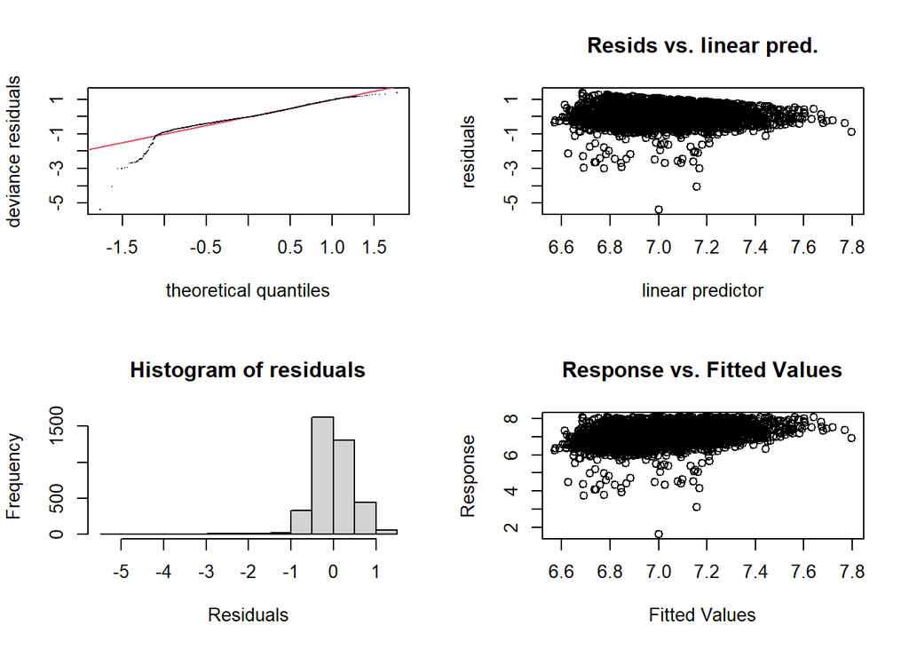

```
##
## Method: GCV   Optimizer: magic
## Model required no smoothing parameter selectionModel rank =  19 / 19
```

```r
# Réglages pour la validation croisée
set.seed(123)
folds <- createFolds(onp$shares, k=10, list=TRUE)

# Pour stocker les RMSE de chaque réplication
RMSEs <- numeric(length(folds))

for(i in seq_along(folds)) {
  # Création des données d'entraînement et de test pour le fold courant
  train_data <- onp[-folds[[i]], ]
  test_data <- onp[folds[[i]], ]

  # Construction du modèle GAM avec les variables sélectionnées
  gam_model <- mgcv::gam(log(shares) ~ num_hrefs + num_self_hrefs +
                           num_imgs + num_videos + num_keywords +
                           as.factor(data_channel_is_entertainment) + as.factor(data_channel_is_bus) +
                           as.factor(data_channel_is_socmed) + as.factor(data_channel_is_tech) +
                           kw_min_min + kw_max_avg + kw_avg_avg +
                           as.factor(weekday_is_monday) + as.factor(weekday_is_tuesday) +
                           as.factor(weekday_is_wednesday) + as.factor(weekday_is_thursday) +
                           as.factor(weekday_is_friday) + as.factor(weekday_is_saturday),
                         data = train_data)

  # Évaluation du modèle sur les données de test du fold courant
  pred <- predict(gam_model, newdata=test_data, type="response")
  actual <- log(test_data$shares + 1)
  RMSEs[i] <- sqrt(mean((pred - actual)^2))
}
```

Le deuxième graphique des résidus contre les valeurs prédites linéaires affiche une dispersion aléatoire des résidus autour de zéro sans motifs apparents, suggérant que le modèle prend bien en compte la variance des données.

## D. SVR:

Le modèle SVR (Support Vector Regression) a été construit et évalué à l’aide de la méthode de rééchantillonnage bootstrap avec un ensemble de données spécifique. Pour assurer la reproductibilité, deux graines ont été définies à des étapes différentes du processus. L’utilisation de 49 rééchantillonnages bootstrap indique un effort pour obtenir une estimation stable de la performance du modèle.

L’entraînement a été réalisé parallèlement pour améliorer l’efficacité, en laissant un cœur libre pour les processus du système, ce qui est une bonne pratique pour ne pas surcharger la machine hôte. L’hyperparamètre C du modèle SVR a été ajusté sur une grille de valeurs logarithmiquement espacées, une approche commune pour optimiser des modèles avec des paramètres qui peuvent opérer sur des ordres de grandeur différents.

La méthode svmLinear a été choisie pour l’entraînement, impliquant que l’on travaille avec un SVR linéaire, surtout quand la relation entre les variables et la réponse est inconnue ou supposée être globalement linéaire.

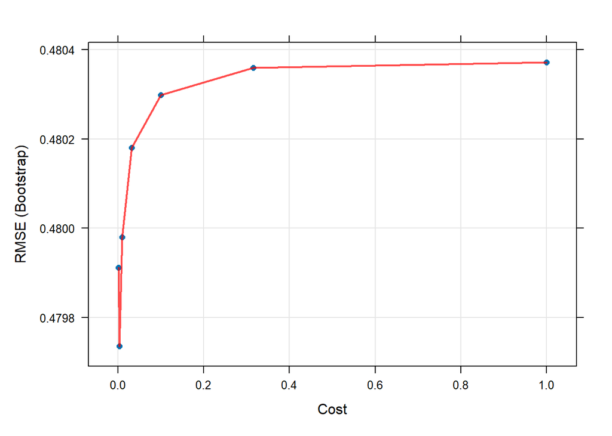

```r
library(caret)
library(doParallel)
library(bootstrap)
library(caret)
library(doParallel)

set.seed(202)
bootCtrl <- trainControl(
  method = "boot",
  number = 49,
  savePredictions = TRUE,
  allowParallel = TRUE
)

cl <- makeCluster(detectCores() - 1)
registerDoParallel(cl)

GridC <- expand.grid(C = 10^seq(-3, 0, by = 0.5))

set.seed(1410)
svr_linear <- train(
  log(shares) ~ ., data = onp1, method = "svmLinear",
  trControl = bootCtrl, preProcess = c("center", "scale"),
  tuneGrid = GridC
)

stopCluster(cl)
registerDoSEQ()
plot(svr_linear)
```

Le graphique affiché illustre le résultat de la performance du modèle en fonction de l’hyperparamètre C. La métrique utilisée est la RMSE (Root Mean Squared Error) calculée à partir des rééchantillonnages bootstrap. La courbe suggère qu’un faible C (0.003162278) est optimal selon le critère de sélection, ce qui suggère une certaine robustesse.

```
##             C
## 2 0.003162278
```

```r
library(DALEX)
library(caret)

features <- onp1[, which(names(onp1) != "shares")]

custom_predict <- function(model, newdata) {
  predict(model, newdata)
}


explainer_svrlinear <- DALEX::explain(
  model = svr_linear$finalModel,
  data = features,
  y = log(onp1$shares),
  predict_function = custom_predict,
  label = "SvrLinear"
)
```

[output not shown]

## E. Les Méthodes de pénalisation:

Les méthodes de pénalisation, telles que Ridge, Lasso et Elastic Net, constituent des approches sophistiquées pour la régularisation des modèles prédictifs. Elles sont particulièrement efficaces pour gérer la multicollinéarité entre les variables prédictives et pour sélectionner les variables les plus significatives dans des ensembles de données de grande dimension. La méthode Ridge applique une pénalité proportionnelle au carré des coefficients, permettant de réduire leur magnitude sans pour autant les annuler. Le Lasso, en revanche, peut réduire certains coefficients à zéro, réalisant ainsi une sélection de variables. Elastic Net combine les atouts de ces deux approches, offrant une solution robuste pour les modèles confrontés à de multiples variables corrélées. L’application de ces techniques vise à améliorer la performance prédictive des modèles tout en maintenant leur simplicité et leur interprétabilité.

### E.1 RIDGE:

Le modèle Ridge, aussi connu sous le nom de régression ridge, est une technique de régularisation qui s’applique pour contrôler la complexité des modèles de régression. En ajoutant un terme de pénalité, qui est proportionnel au carré des coefficients de régression, à la fonction de coût, le modèle Ridge vise à minimiser l’impact de la multicollinéarité entre les variables prédictives. Cette approche permet de réduire la variance des estimations des coefficients, améliorant ainsi la stabilité et la performance du modèle sur des données non vues, tout en évitant le surajustement. En dépit de réduire la taille des coefficients, la régression Ridge ne les ramène pas exactement à zéro, ce qui signifie que toutes les variables initiales restent dans le modèle final. Cette caractéristique fait du modèle Ridge un outil précieux lorsque l’objectif est de conserver l’information de toutes les variables prédictives tout en contrôlant pour la surcomplexité du modèle

```r
library(caret)
library(glmnet)

# Préparation des données
set.seed(123) # Pour la reproductibilité
data <- onp1
data$shares <- log(data$shares + 1) # Appliquer le log

# Créer un ensemble d'entraînement et de test
index <- createDataPartition(data$shares, p = 0.7, list = FALSE)
trainData <- data[index, ]
testData <- data[-index, ]

# Définir le contrôle de la formation avec une validation croisée de 10 plis
trainControl <- trainControl(method = "cv", number = 10)

# Grille de recherche pour lambda (alpha = 0 pour Ridge)
grid <- expand.grid(.lambda = 10^seq(-3, 3, length = 100),
                    .alpha = 0)

# Entraînement du modèle Ridge
ridgeModel <- train(formula, data = trainData,
                    method = "glmnet",
                    trControl = trainControl,
                    tuneGrid = grid)

predictions <- predict(ridgeModel, newdata = testData)

RMSE <- sqrt(mean((predictions - log(testData$shares + 1))^2))
cat("RMSE pour le modèle Ridge :", RMSE, "\n")
```

```
## RMSE pour le modèle Ridge : 0.1462139
```

```r
# Visualisation des résultats
print(head(ridgeModel))
```

[output not shown]

[output cut: 387 more lines]

[output not shown]

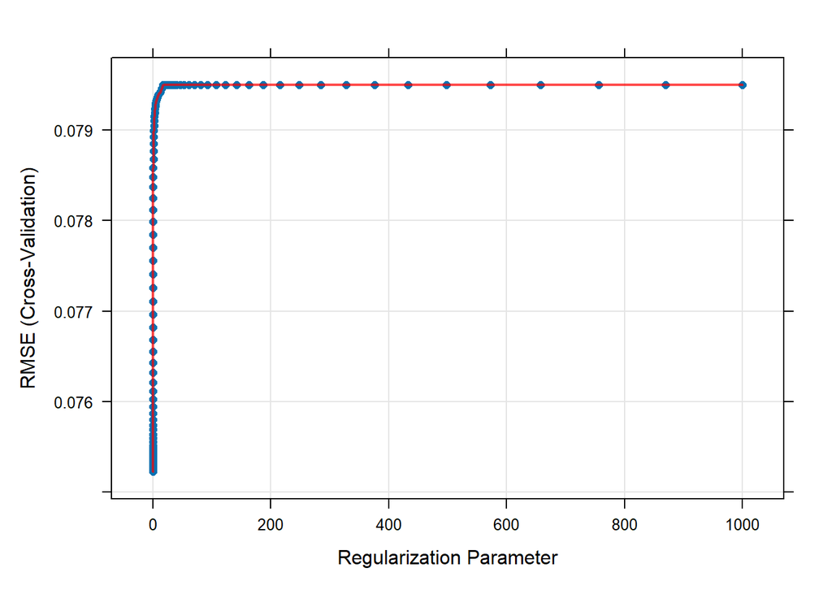

```
## [1] 0.00152
```

```r
plot(ridgeModel)
```

|  | x |
| --- | --- |
| (Intercept) | 1.93 |
| global_rate_negative_words | -0.64 |
| global_rate_positive_words | 0.36 |
| global_sentiment_polarity | -0.10 |
| avg_negative_polarity | 0.05 |
| min_positive_polarity | -0.03 |
| avg_positive_polarity | 0.03 |
| weekday_is_thursday | -0.03 |
| weekday_is_tuesday | -0.03 |
| data_channel_is_socmed | 0.03 |
| weekday_is_wednesday | -0.03 |
| data_channel_is_tech | 0.03 |
| weekday_is_monday | -0.03 |
| n_non_stop_unique_tokens | -0.02 |
| title_sentiment_polarity | 0.02 |
| weekday_is_friday | -0.02 |
| weekday_is_saturday | 0.02 |
| global_subjectivity | 0.02 |
| data_channel_is_lifestyle | -0.02 |
| data_channel_is_bus | 0.02 |
| data_channel_is_entertainment | -0.01 |
| average_token_length | -0.01 |
| max_negative_polarity | -0.01 |
| max_positive_polarity | -0.01 |
| abs_title_sentiment_polarity | -0.01 |
| num_videos | 0.01 |
| min_negative_polarity | -0.01 |
| num_imgs | 0.00 |
| title_subjectivity | 0.00 |
| kw_min_min | 0.00 |
| num_keywords | 0.00 |
| num_self_hrefs | 0.00 |
| num_hrefs | 0.00 |
| n_tokens_title | 0.00 |
| kw_avg_avg | 0.00 |
| kw_avg_min | 0.00 |
| n_tokens_content | 0.00 |
| kw_min_avg | 0.00 |
| timedelta | 0.00 |
| kw_max_avg | 0.00 |
| kw_max_min | 0.00 |
| kw_min_max | 0.00 |
| kw_avg_max | 0.00 |

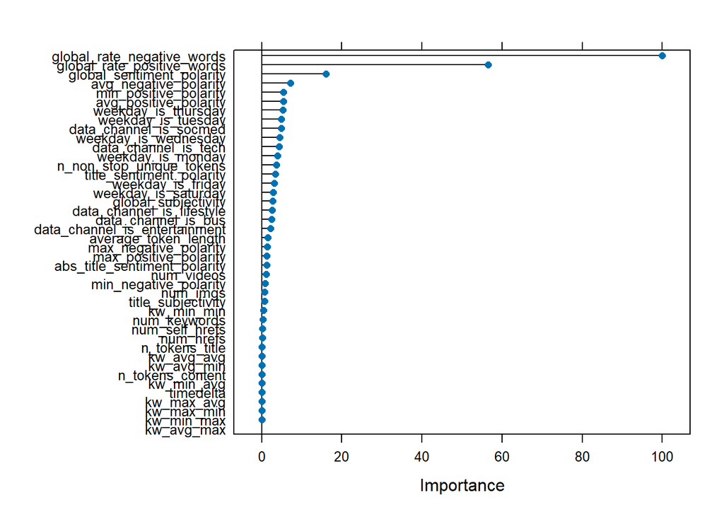

### E.2 LASSO

Le modèle LASSO (Least Absolute Shrinkage and Selection Operator) est une technique de régression qui réalise à la fois la sélection de variables et la régularisation afin d’améliorer la précision de la prédiction et l’interprétabilité du modèle statistique produit. En ajoutant une pénalité sur la somme des valeurs absolues des coefficients de régression, le LASSO tend à produire des modèles avec un nombre restreint de paramètres, réduisant ainsi les coefficients de certaines variables à zéro et éliminant effectivement ces variables du modèle final. Cette méthode est particulièrement utile dans les situations où le nombre de variables explicatives est très grand par rapport au nombre d’observations.

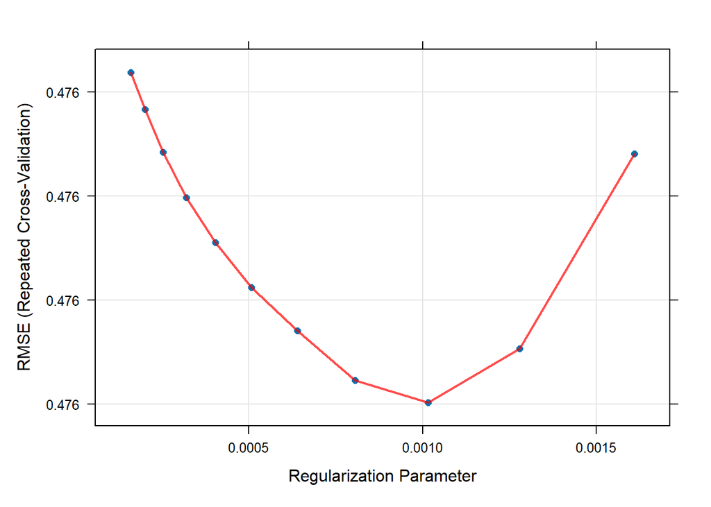

```r
numbers <- 5
repeats <- 20
rcvTunes <- 11

nrcore <- 8
cl <- makeCluster(mc <- getOption("cl.cores", nrcore))
registerDoParallel(cl)

lambda <- 10^(-seq(3.5, 2.5, length = rcvTunes))*sd(log(onp$shares + 1))

set.seed(123)
rcvControl <- trainControl(method = "repeatedcv",
                           number = numbers,
                           repeats = repeats,
                           search = "random")

lasso <- train(formula, data = onp1,
               method = "glmnet",
               trControl = rcvControl,
               preProcess = c("center", "scale"),
               tuneGrid = expand.grid(alpha = 1,
                                      lambda = lambda))
stopCluster(cl)
plot(lasso)
```

La courbe pour le modèle Lasso montre une décroissance rapide de l’erreur de validation croisée RMSE avec l’augmentation du paramètre de régularisation jusqu’à atteindre un creux, indiquant le lambda optimal. Au-delà de ce point, l’erreur augmente, ce qui signifie que le modèle devient moins performant pour des valeurs de lambda plus élevées. Le meilleur lambda identifié est 0.00102, qui offre un compromis idéal entre biais et variance, aboutissant à la meilleure généralisation possible du modèle sur de nouvelles données.

```
## [1] 0.00102
```

Le lambda optimal de 0.00102 pour le modèle Lasso indique la quantité de pénalisation appliquée pour minimiser la suradaptation. À ce niveau de régularisation, le modèle conserve les caractéristiques pertinentes tout en éliminant celles qui contribuent le moins à la prédiction, permettant ainsi un équilibre entre la complexité du modèle et son pouvoir prédictif. Ce paramètre est sélectionné pour optimiser les performances du modèle sur des données non vues en contrôlant la complexité et en promouvant la parcimonie dans les caractéristiques utilisées.

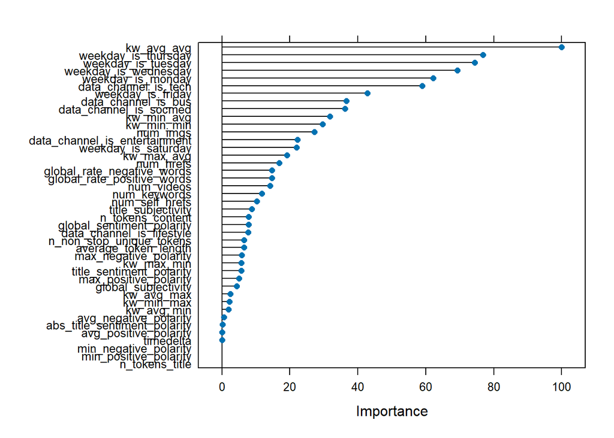

Sur le modèle Lasso, on se retrouve avec d’autres variables importante tel que kw_avg_avg et les jours de publications des articles et le nombre d’images, on a aussi d’autres types de variables beaucoup pris en compte, comme celle de la négativité du contenue.

### E.3 Elastic Net

Le modèle Elastic Net combine les atouts de la régularisation Ridge et LASSO, permettant de gérer la multicollinéarité entre les prédicteurs tout en réalisant une sélection de variables. Cette approche est particulièrement utile dans le contexte de notre prédiction du nombre de partages log(shares), car elle nous aide à construire un modèle robuste et parcimonieux, optimisant la prédiction tout en réduisant la complexité du modèle et le risque de surajustement.

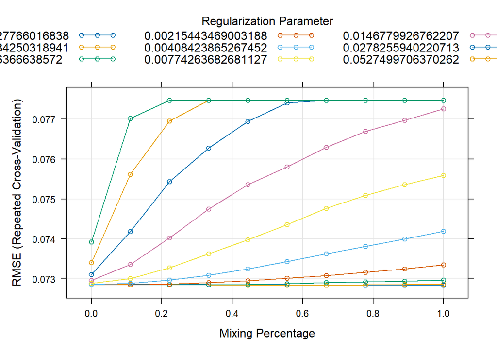

```r
library(caret)
library(glmnet)
library(doParallel)

# Préparer les données
data <- onp1
data$shares <- log(data$shares + 1) # Pour assurer que toutes les valeurs sont positives

# Définir les paramètres pour la validation croisée
numbers <- 5 # Nombre de folds pour la cross-validation
repeats <- 5 # Nombre de répétitions pour la cross-validation
nrcore <- detectCores() - 1 # Nombre de cœurs à utiliser, un de moins pour éviter de surcharger la machine

# Créer un cluster parallèle
cl <- makeCluster(nrcore)
registerDoParallel(cl)

# Grille de paramètres pour Elastic Net
lambda <- 10^seq(-3.5, -1, length = 10)
alpha <- seq(0, 1, length = 10)

# Contrôle de l'entraînement
rcvControl <- trainControl(method = "repeatedcv",
                           number = numbers,
                           repeats = repeats,
                           search = "random",
                           allowParallel = TRUE)

# Entraînement du modèle Elastic Net
set.seed(123)
enetModel <- train(log(shares) ~ ., data = data,
                   method = "glmnet",
                   trControl = rcvControl,
                   tuneGrid = expand.grid(alpha = alpha, lambda = lambda),
                   preProcess = c("center", "scale"))

# Arrêter le cluster parallèle
stopCluster(cl)
registerDoSEQ()

# Visualiser les performances du modèle
plot(enetModel)
```

```
## [1] 1
```

```
## [1] 0.000316
```

Le meilleur alpha de 1 indique que le modèle Elastic Net privilégie une approche Lasso pure, mettant l’accent sur la sélection de variables par réduction de leurs coefficients vers zéro. Le meilleur lambda de 0.000316 offre le niveau de régularisation idéal, réduisant la complexité du modèle pour éviter la suradaptation tout en conservant suffisamment de flexibilité pour capturer les relations significatives dans les données.

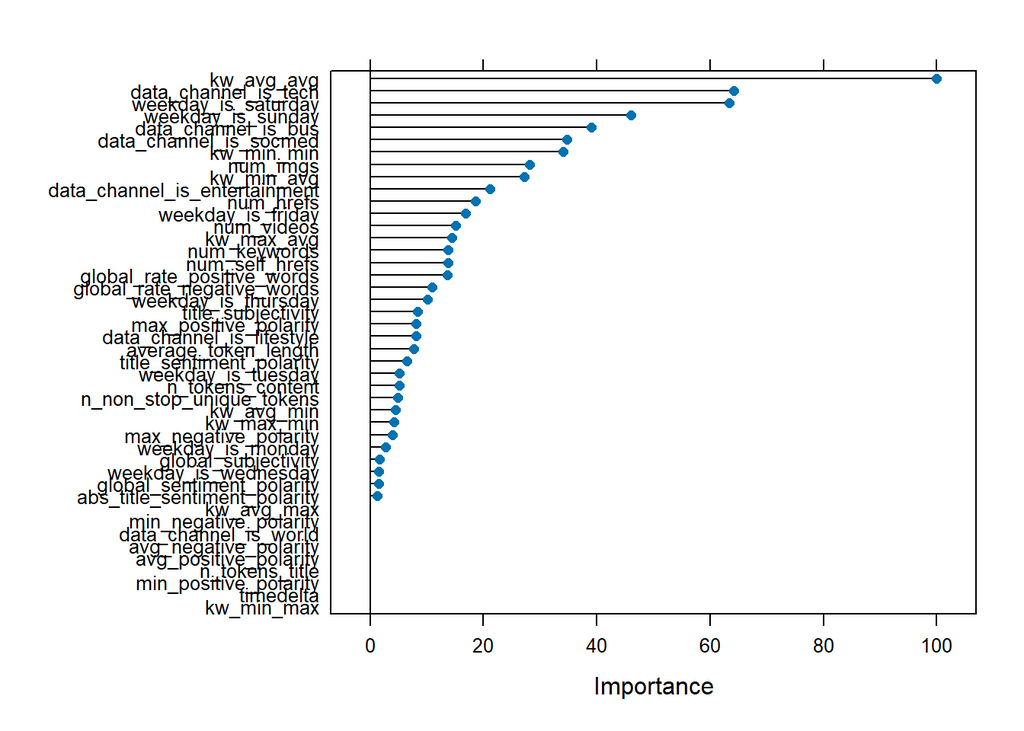

# V. Comparaison des modèles:

Dans cette section, nous nous consacrons à l’évaluation comparative de nos modèles prédictifs concernant le nombre de partages d’articles en ligne. Notre objectif est de mesurer la performance de ces modèles en les juxtaposant aux résultats obtenus par Fernandes et al. dans leur étude. Cette démarche vise à situer l’efficacité de nos approches dans un contexte élargi, en mettant en perspective les avancées méthodologiques et les résultats quantitatifs que nous avons réalisés par rapport à des travaux antérieurs dans le domaine. Cette comparaison permettra d’identifier les atouts et les limites de nos modèles et d’explorer les voies d’optimisation possibles pour accroître la précision de nos prédictions sur la popularité des contenus en ligne.

L’étude présente un Système de Support Décisionnel Intelligent (IDSS) innovant pour prédire la popularité des actualités en ligne avant leur publication, puis pour optimiser les caractéristiques des articles afin d’améliorer la probabilité de popularité prédite. En exploitant un ensemble de données des articles du site Mashable, cinq modèles ont été testés. Le modèle Random Forest s’est distingué avec une puissance de discrimination de 73%. En outre, l’optimisation des articles via des recherches locales en escalade stochastique a montré une amélioration moyenne significative de 15 points de pourcentage en termes de probabilité de popularité estimée. Cette IDSS, qui combine prédiction et optimisation, offre un outil précieux pour les auteurs d’actualités en ligne, leur permettant d’augmenter le potentiel de popularité de leurs articles. Cette approche proactive et novatrice représente une avancée notable dans le domaine de la gestion et de la prédiction du contenu en ligne.

## Analyse des modèles regressionnels mis en place:

Durant notre projet, contrairement aux prédictions mise en place dans la revue, on a opté pour des modèles de regression et cela pour prédire un nombre proche du nombre de partage des articles. Pour évaluer ces modèles on s’interesse à la RMSE, Racine Carrée de l’Erreur Quadratique Moyenne, qui est une métrique d’évaluation pour les modèles de régression qui mesure la racine carrée de la moyenne des carrés des écarts entre les valeurs prédites et les valeurs observées. Elle offre une évaluation de la performance du modèle en termes de précision des prédictions, avec des valeurs plus basses indiquant un meilleur ajustement du modèle aux données.

Prenant en compte les RMSE des modèles utilisés, on peut obtenir le graphique suivant.

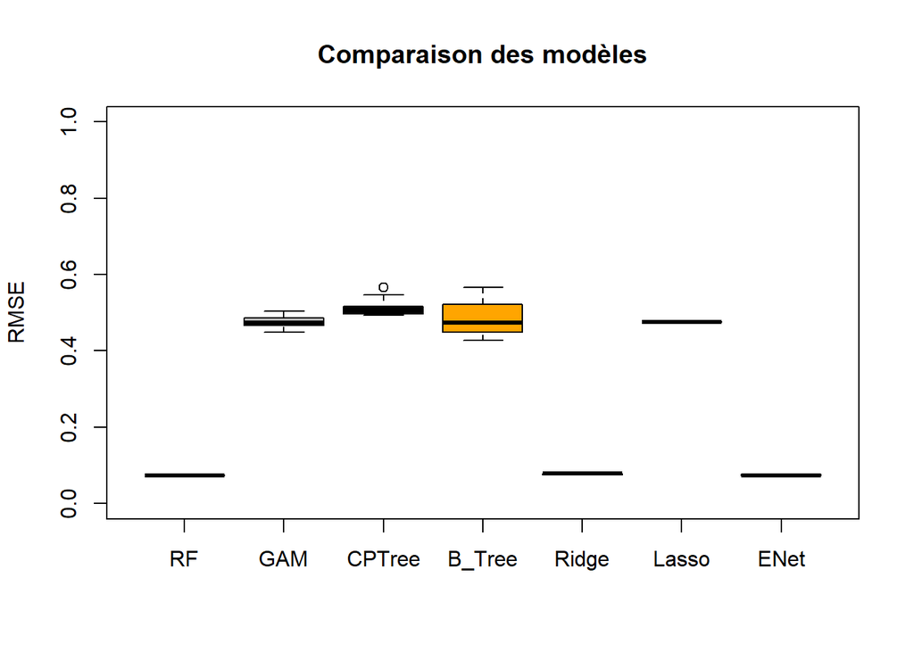

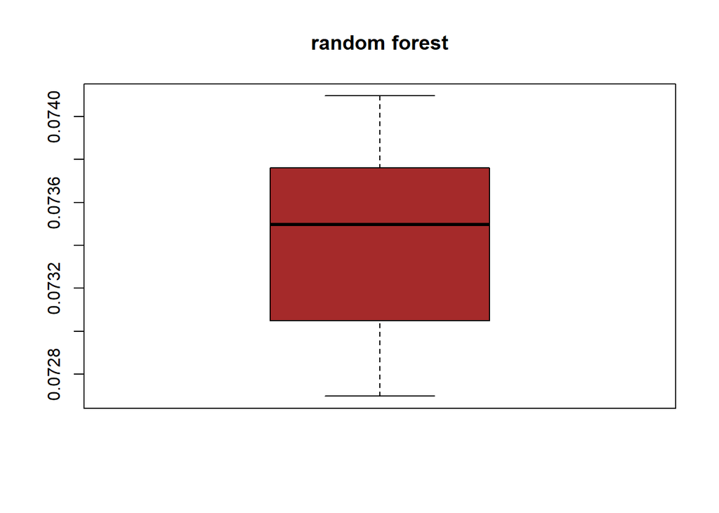

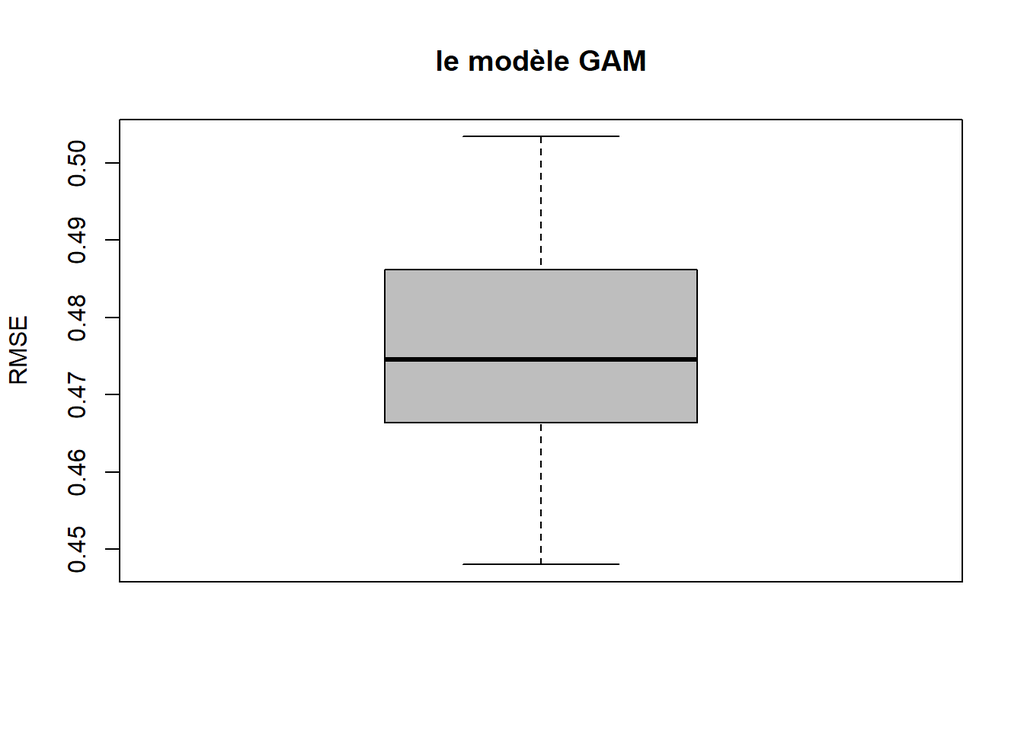

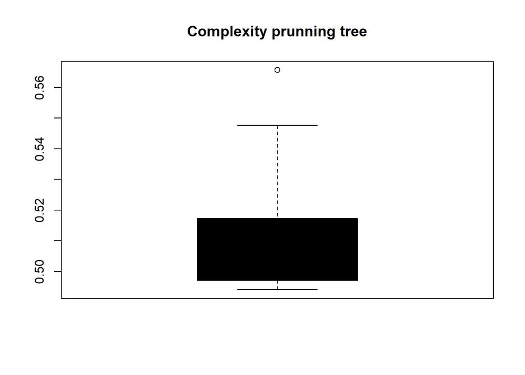

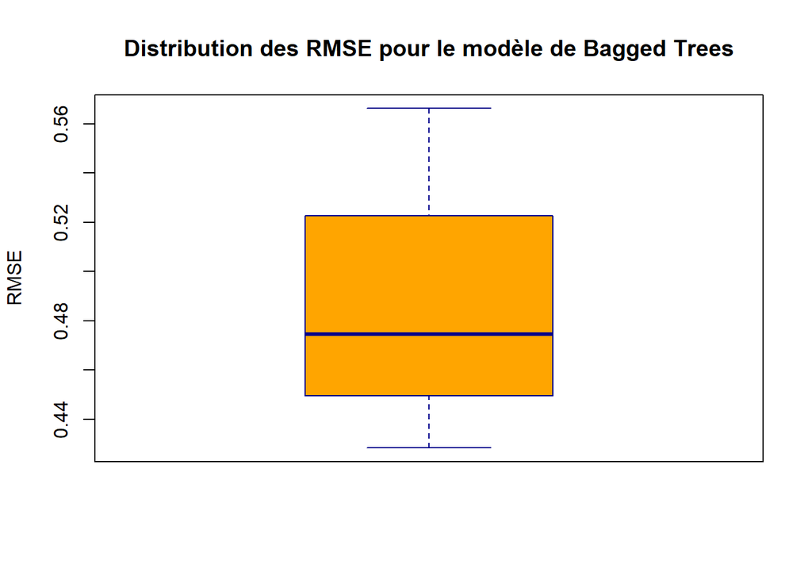

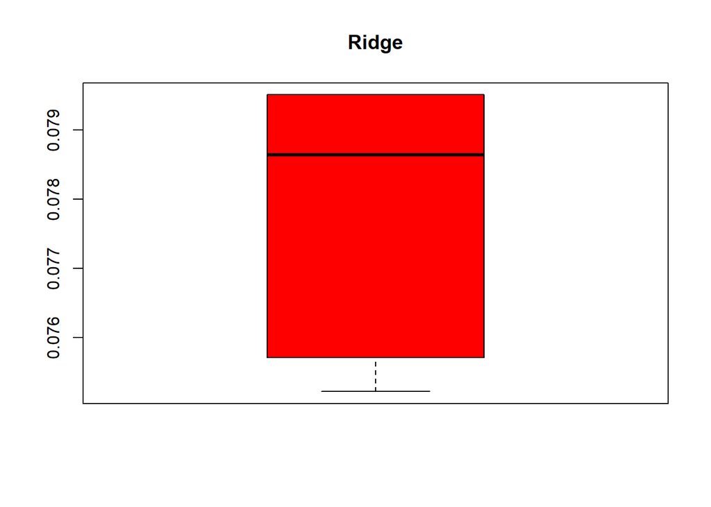

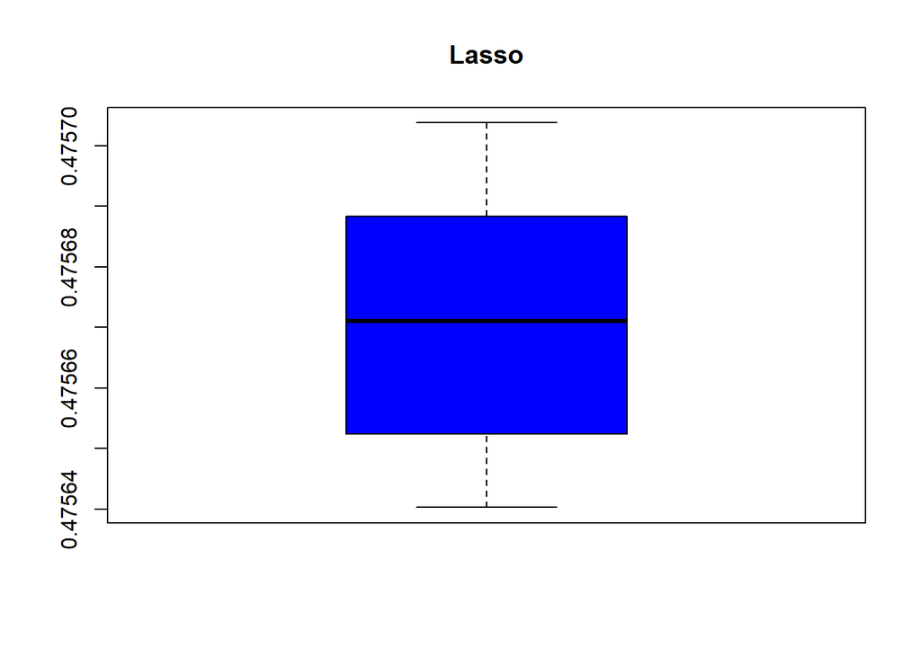

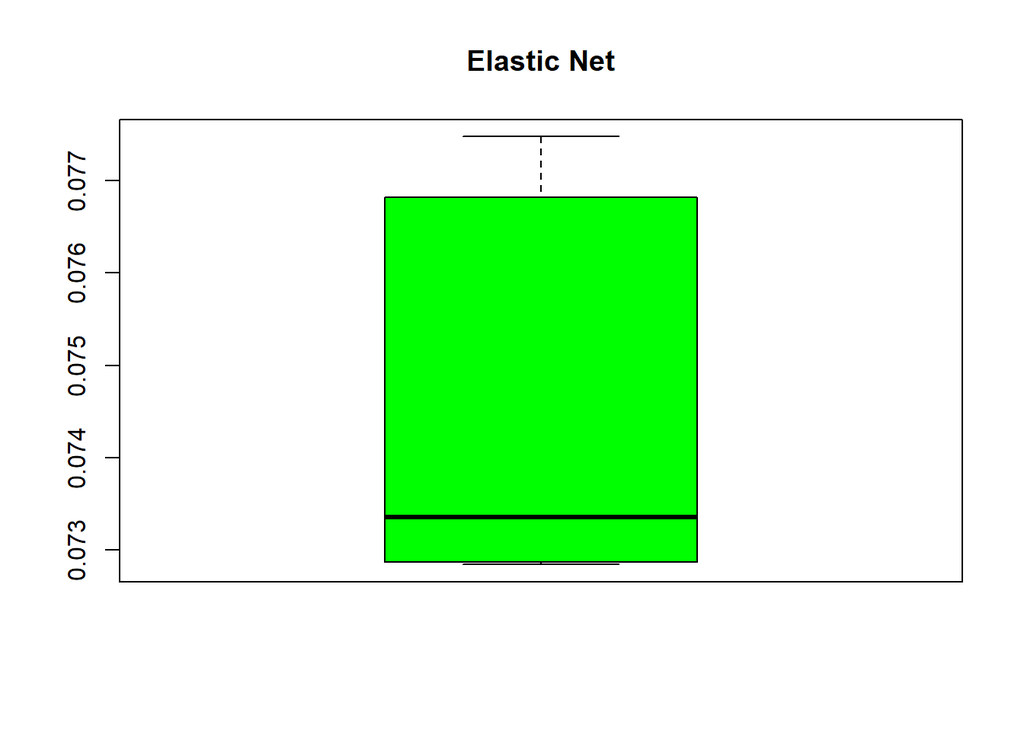

Le boxplot de comparaison des modèles illustre la distribution de l’erreur quadratique moyenne (RMSE) pour différents modèles de régression appliqués à la prédiction du nombre de partages d’articles. Les modèles incluent Random Forest (RF), Generalized Additive Models (GAM), Complexity Pruning Tree (CPTree), Bagged Trees (B_Tree), Ridge Regression, Lasso et Elastic Net (ENet).

## Prédiction chiffré avec le meilleur modèle:

Dans le cadre de notre analyse, nous avons identifié le modèle de forêt aléatoire (Random Forest) comme étant le plus performant pour prédire le nombre de partages d’articles. En vue d’une application pratique de ce modèle, nous mettons un accent particulier sur l’estimation des intervalles de confiance pour les prédictions obtenues. L’élaboration de ces intervalles est cruciale, car elle fournit une mesure de l’incertitude associée à chaque prédiction et enrichit ainsi notre compréhension de la variabilité des données. Ces intervalles, calculés à un niveau de confiance de 90%, permettent non seulement d’encadrer les prévisions, mais offrent également une fourchette dans laquelle les valeurs réelles sont susceptibles de se situer. Cette approche contribue à renforcer la fiabilité des prédictions et sert d’outil décisionnel précieux pour évaluer la portée potentielle des articles dans des conditions diverses et variables.

```
##   predicted lower_bound upper_bound real_value
## 1      6.77        5.98        7.56       6.91
## 2      6.53        5.74        7.32       4.91
## 3      6.96        6.17        7.75       7.38
## 4      7.02        6.23        7.82       7.09
## 5      7.01        6.22        7.81       7.50
## 6      6.97        6.18        7.77       6.84
```

Dans cette analyse, nous avons renversé la log-transformation appliquée à nos prédictions et valeurs réelles en utilisant la fonction exponentielle. Cette étape est cruciale pour ramener nos prédictions à l’échelle originale des partages et rendre nos résultats interprétables dans le contexte réel. Ensuite, nous avons calculé la différence en pourcentage entre les valeurs réelles de partages et celles prédites pour évaluer la précision de notre modèle. Nous avons également déterminé si les valeurs réelles se situaient dans les intervalles de confiance prédits, fournissant ainsi une mesure de la fiabilité de nos prédictions. Le pourcentage de prédictions correctes reflète la proportion de fois où le modèle a réussi à capturer la vraie valeur des partages à l’intérieur de l’intervalle prédit, ce qui donne un aperçu significatif de l’efficacité du modèle en termes de précision et de fiabilité des prédictions.

```
## Pourcentage de partages bien prédits (dans l'intervalle de prédiction) : 91.7 %
```

```
##   predicted lower_bound upper_bound real_value perc_diff in_interval
## 1       870         394        1924       1000     12.98        TRUE
## 2       686         310        1516        134    411.65       FALSE
## 3      1053         476        2327       1600     34.21        TRUE
## 4      1121         507        2478       1200      6.58        TRUE
## 5      1110         502        2453       1800     38.34        TRUE
## 6      1068         483        2360        935     14.18        TRUE
##   closest_bound closest_perc_diff
## 1           606              60.6
## 2           176             131.5
## 3           727              45.4
## 4           693              57.7
## 5           653              36.3
## 6           452              48.3
```

Le modèle de forêt aléatoire a démontré une capacité remarquable à prédire avec précision le nombre de partages d’articles, avec un taux impressionnant de plus de 90% des prédictions tombant dans l’intervalle de prédiction à 90% de confiance. Ce niveau de performance indique non seulement que le modèle est bien ajusté et capture efficacement la variabilité inhérente aux données, mais aussi qu’il possède une forte capacité de généralisation à de nouvelles données non observées pendant l’entraînement. L’utilisation d’intervalles de prédiction offre un aperçu supplémentaire sur la fiabilité des prédictions, fournissant une mesure quantitative de l’incertitude associée à chaque prédiction. Cette approche renforce la confiance dans la capacité du modèle à être utilisé dans des applications pratiques, où comprendre la gamme probable des résultats est tout aussi critique que la prédiction elle-même.

# VI. Conclusion:

Au cours de notre étude, nous avons exploré la prédiction du nombre de partages d’articles en ligne à travers divers modèles de régression, cherchant à optimiser notre compréhension des facteurs influençant la popularité des contenus numériques.

Cette analyse nous a non seulement permis d’évaluer l’efficacité de différentes stratégies de modélisation mais a aussi offert des insights précieux sur les éléments essentiels à considérer dans la création de contenus engageants et largement partagés sur les plateformes numériques.

Notre travail peut contribuer à une meilleure compréhension de la dynamique de partage des articles en ligne, offrant une base solide pour de futures recherches et applications pratiques dans le domaine du marketing de contenu et de l’analyse prédictive, et cela de manière differente de celle utilisée par Fernandes et al. dans leurs travail de prédiction par catégorie.